# Lab 9: Baby Names

Author

Jamie Thompson

### Setup

```r
library(RColorBrewer)
library(tidyverse)
library(ggtext)
```

## **The Data**

The data in this lab contains many baby names and how many babies were named each name per each state over a set of years (1997 - 2014). At [this link](https://www.dropbox.com/sh/czm61yzmvzl6xfb/AABEFdpy02aNRhZ_vcxrVAQSa?dl=0), you can find the names for ALL 50 states, in separate datasets organized by first letter.

#### **Question to be evaluated: Is Dr. Theobold’s first name not cool any more?**

For a majority of this lab, I will look at the name “Allison” and how it has changed over time. Since her name begins with “A”, I downloaded the `StateNames_A.csv` and import in it below.

```r
StateNames_A <- read.csv(here::here("supporting_artifacts",
                                    "learning_targets",
                                    "Data",
                                    "StateNames_A.csv")
                         )
```

## **Summarizing & Visualizing the Number of Allison’s**

1. First summary table asked: Number of female and males named ‘Allison’ per each state.

```r
StateAllison <- StateNames_A |>
  mutate(Gender = as.factor(Gender),
         Gender = fct_recode(Gender,
                             Female = "F",
                             Male = "M")
         ) |>
  pivot_wider(names_from = Gender,
              values_from = Count) |>
  group_by(State) |>
  filter(Name == "Allison") |>
  summarise(across(Female:Male, sum),
            across(Female:Male, ~replace_na(., 0))
            )


knitr::kable(StateAllison,
             col.names = gsub(pattern = "[.]",
                              replacement = " ",
                              x = names(StateAllison)),
             align = "ccc",
             caption = "Number of Babies named Allison per State.")
```

Number of Babies named Allison per State.

| State | Female | Male |
| --- | --- | --- |
| AK | 232 | 0 |
| AL | 1535 | 0 |
| AR | 1198 | 0 |
| AZ | 1880 | 0 |
| CA | 12413 | 0 |
| CO | 1594 | 0 |
| CT | 1099 | 0 |
| DC | 321 | 0 |
| DE | 294 | 0 |
| FL | 4455 | 0 |
| GA | 3257 | 0 |
| HI | 183 | 0 |
| IA | 1477 | 0 |
| ID | 451 | 0 |
| IL | 5110 | 0 |
| IN | 3067 | 0 |
| KS | 1283 | 0 |
| KY | 1905 | 0 |
| LA | 1209 | 0 |
| MA | 2218 | 0 |
| MD | 2229 | 0 |
| ME | 340 | 0 |
| MI | 4014 | 0 |
| MN | 2374 | 0 |
| MO | 2882 | 0 |
| MS | 817 | 0 |
| MT | 226 | 0 |
| NC | 3435 | 0 |
| ND | 285 | 0 |
| NE | 807 | 0 |
| NH | 412 | 0 |
| NJ | 3052 | 0 |
| NM | 399 | 0 |
| NV | 729 | 0 |
| NY | 5747 | 0 |
| OH | 5487 | 0 |
| OK | 1421 | 0 |
| OR | 1186 | 0 |
| PA | 4307 | 0 |
| RI | 306 | 0 |
| SC | 1228 | 0 |
| SD | 376 | 0 |
| TN | 2488 | 0 |
| TX | 10192 | 0 |
| UT | 1125 | 0 |
| VA | 3220 | 0 |
| VT | 135 | 0 |
| WA | 1956 | 0 |
| WI | 2367 | 0 |
| WV | 813 | 0 |
| WY | 142 | 0 |

## Evidence 1 (All of question 2)

2. Adjustment of table above: Selecting only Female’s because “Allison” is a name given overwhelmingly to babies assigned female at birth.

There are two attempts at this below, both demonstrating issues. I wanted to make this table have two columns so it isn’t as long.

The fist attempt below just looks terrible, and is all I could find on the googles. I cant figure out how to get it to be aligned properly or fill the space pretty. In the book, it has `booktabs = TRUE, valign = 't'` however after removing and/or adding those things, they did nothing. You can try yourself by removing the `#` on the code.

```r
# first attempt
FemaleAllison <- StateAllison |>
  select(State, Female)

knitr::kable(list(FemaleAllison[1:26,], FemaleAllison[27:51,]),
             # booktabs = TRUE, valign = 't',
          # these specification above dont do anything visually.
             caption = "Number of Female Babies named Allison.")
```

Number of Female Babies named Allison.

| State | Female |
| --- | --- |
| AK | 232 |
| AL | 1535 |
| AR | 1198 |
| AZ | 1880 |
| CA | 12413 |
| CO | 1594 |
| CT | 1099 |
| DC | 321 |
| DE | 294 |
| FL | 4455 |
| GA | 3257 |
| HI | 183 |
| IA | 1477 |
| ID | 451 |
| IL | 5110 |
| IN | 3067 |
| KS | 1283 |
| KY | 1905 |
| LA | 1209 |
| MA | 2218 |
| MD | 2229 |
| ME | 340 |
| MI | 4014 |
| MN | 2374 |
| MO | 2882 |
| MS | 817 |

| State | Female |
| --- | --- |
| MT | 226 |
| NC | 3435 |
| ND | 285 |
| NE | 807 |
| NH | 412 |
| NJ | 3052 |
| NM | 399 |
| NV | 729 |
| NY | 5747 |
| OH | 5487 |
| OK | 1421 |
| OR | 1186 |
| PA | 4307 |
| RI | 306 |
| SC | 1228 |
| SD | 376 |
| TN | 2488 |
| TX | 10192 |
| UT | 1125 |
| VA | 3220 |
| VT | 135 |
| WA | 1956 |
| WI | 2367 |
| WV | 813 |
| WY | 142 |

This next attempt looks great! However no matter what I tried, the caption will not appear at the top (its at bottom). I tried using hash-pipes seen below, but the specification of `#| cap-location: top` OR `#| fig-cap-location: top` AND the `caption = "..."` within the `kable()` function do not work. Again, you can try yourself by removing the `#` on the code.

```r
# attempt 2

FemaleAllison <- StateAllison |>
  select(State, Female)

knitr::kable(list(FemaleAllison[1:26,], FemaleAllison[27:51,]),
             format = "simple"
             #caption = "Number of Female Babies named Allison."
          # this caption specification doens't do anything.
)
```

| State | Female |
| --- | --- |
| AK | 232 |
| AL | 1535 |
| AR | 1198 |
| AZ | 1880 |
| CA | 12413 |
| CO | 1594 |
| CT | 1099 |
| DC | 321 |
| DE | 294 |
| FL | 4455 |
| GA | 3257 |
| HI | 183 |
| IA | 1477 |
| ID | 451 |
| IL | 5110 |
| IN | 3067 |
| KS | 1283 |
| KY | 1905 |
| LA | 1209 |
| MA | 2218 |
| MD | 2229 |
| ME | 340 |
| MI | 4014 |
| MN | 2374 |
| MO | 2882 |
| MS | 817 |

| State | Female |
| --- | --- |
| MT | 226 |
| NC | 3435 |
| ND | 285 |
| NE | 807 |
| NH | 412 |
| NJ | 3052 |
| NM | 399 |
| NV | 729 |
| NY | 5747 |
| OH | 5487 |
| OK | 1421 |
| OR | 1186 |
| PA | 4307 |
| RI | 306 |
| SC | 1228 |
| SD | 376 |
| TN | 2488 |
| TX | 10192 |
| UT | 1125 |
| VA | 3220 |
| VT | 135 |
| WA | 1956 |
| WI | 2367 |
| WV | 813 |
| WY | 142 |

Number of Female Babies named Allison.

## Evidence 2: Q. 3

3. Making a visualization showing how the popularity of the name “Allison” has changed over the years.

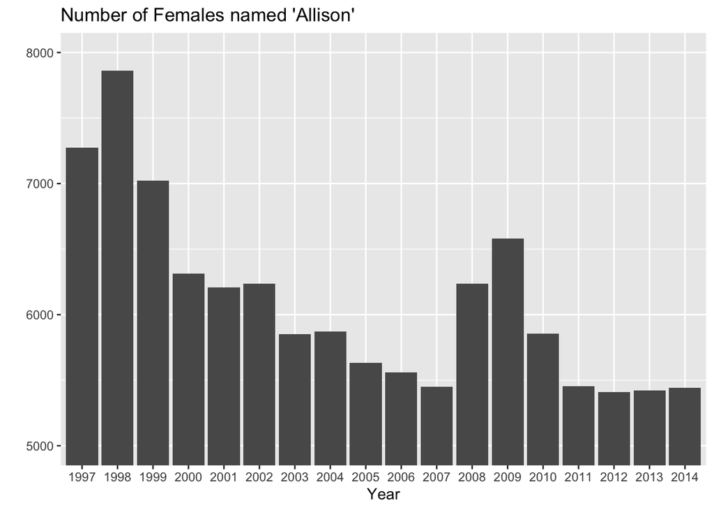

```r
# Creating the Dataset for visualizaiton that I will use later on as well.
Allison <- StateNames_A |>
  filter(Name == "Allison") |>
  mutate(Gender = as.factor(Gender),
         Gender = fct_recode(Gender,
                             Female = "F",
                             Male = "M")
         ) |>
  pivot_wider(names_from = Gender,
              values_from = Count) |>
  group_by(Year) |>
  summarise(across(Female:Male, sum),
            across(Female:Male, ~replace_na(., 0))
  )



# Making the visualization
ggplot(data = Allison, mapping = aes(x = as.factor(Year), y = Female)) +
  geom_col() +
  coord_cartesian(ylim = c(5000, 8000)
                  ) +
  labs(title = "Number of Females named 'Allison'",
       y = "",
       x = "Year")
```

Notes: Found out how to rescale my axis to help emphasize the difference between the bars. I first found out about `ylim()` and `xlim()`, however, that function drops data observations, and I don’t know how to fix it. Upon reading in the Help window about `ylim()`, it recommended `coord_cartesian(ylim())` and it worked perfect!

## **Evidence 3****: Modeling the Number of Allisons (Q. 4-8)**

4. Creating a linear model with the **year** as the explanatory variable, and the **number of Allisons** as the response.

**NOTE**: is this a Time Series Regression model? Since we are using `Year`?

```r
Allison_lm <- lm(Female ~ Year, data = Allison)

Allison_lm
```

```
Call:
lm(formula = Female ~ Year, data = Allison)

Coefficients:
(Intercept)         Year
   209689.8       -101.5
```

5. Visualize the regression model.

Evaluating the graph produced below, the linear regression line produced does show a slight negative linear relationship between `Year` and `Number of Allison's`, which matches with the bar graph above.

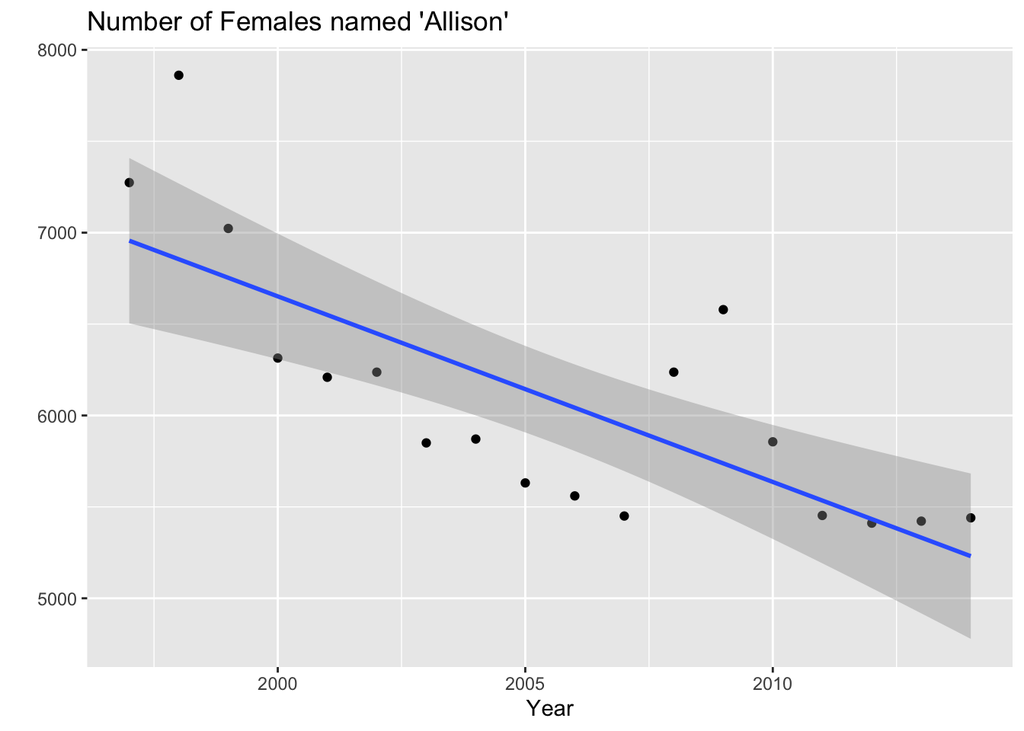

```r
ggplot(data = Allison, mapping = aes(x = Year, y = Female)) +
  geom_point() +
  geom_smooth(method = "lm") +
  labs(title = "Number of Females named 'Allison'",
       y = "",
       x = "Year")
```

6. Write out the estimated regression equation.

`Est. Number of females with Allison name = 209689.8 - 101.5(Year)`

7. Plot the *residuals* of the model, that is, the actual values minus the predicted values. Comment on the residuals - do you see any patterns?

To my knowledge, we usually plot the residuals vs the fitted values.

I don’t really see any obvious patterns, there aren’t many datapoints so it is hard to tell. There may be sight evidence of fanning, which means theresiduals are close to 0 for small x values and are more spread out for large x values. This can indicate a violation of equal constant variance, but its hard to tell so I’ll say it looks OK!

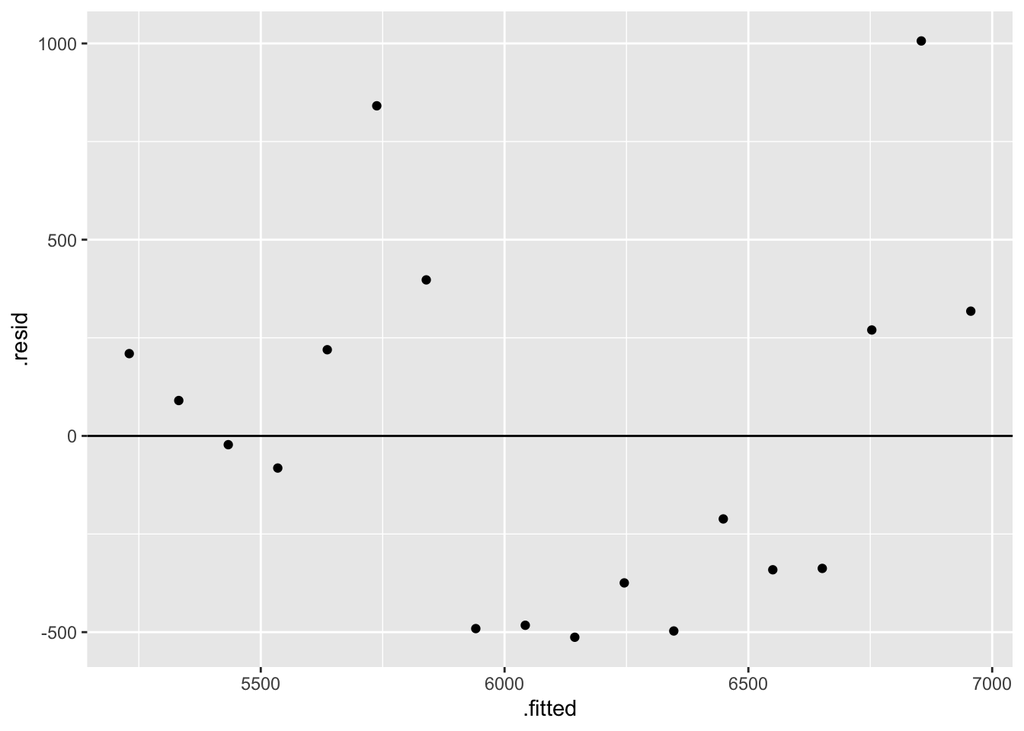

```r
Allison_lm |>
  broom::augment() |>
  ggplot(mapping = aes(y = .resid, x = .fitted)
         ) +
  geom_point() +
  geom_hline(yintercept = 0)
```

8. What do you conclude from this model?

With linear regression, assumptions that need to be checked are:

- linearity
  - Evaluating the visualization of the linear model in number 5, it does appear linear.
- independence
  - Independence especially needs to be checked in time series regression models, which I believe this is.
  - Below is the graph I know can be used to check independence of time series plots, but to be honest, I don’t remember how to tell if it passes or fails the independence check.

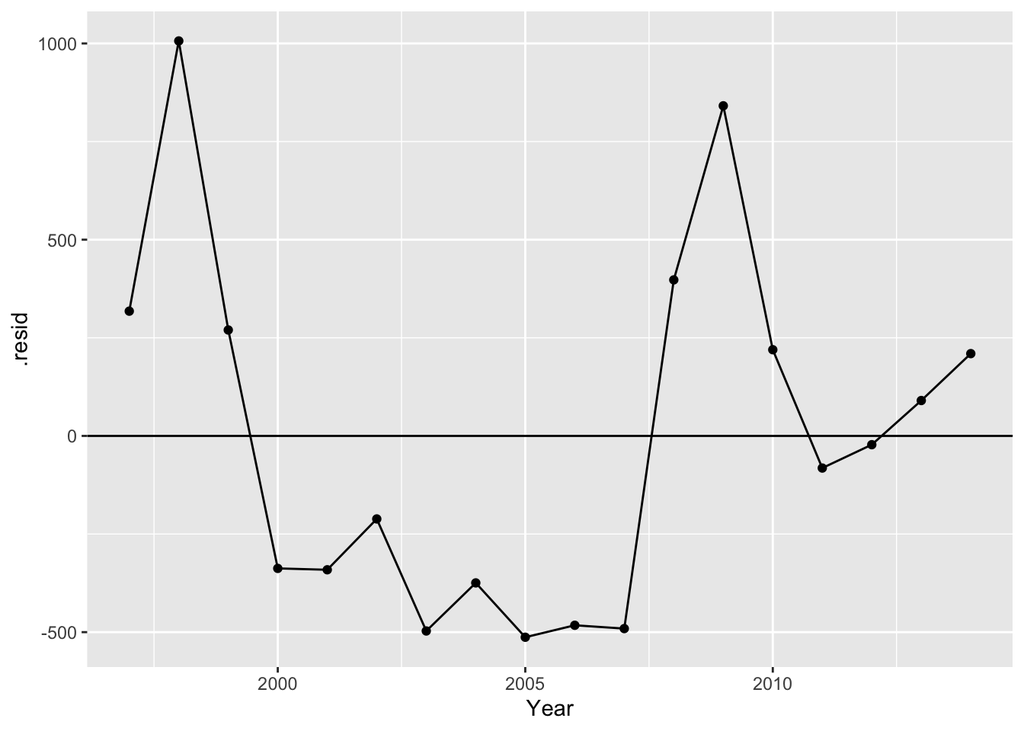

```r
Allison_lm |>
  broom::augment() |>
  ggplot(mapping = aes(y = .resid, x = Year)
         ) +
  geom_line() +
  geom_point() +
  geom_hline(yintercept = 0)
```

- equal constant variance
  - As seen in number 7 with the plot of residuals vs fitted values, I concluded equal constant variaence was OK.
- normality
  - Below is as far as I could get to making a normal probability plot… Got the help from http://www.r-tutor.com/elementary-statistics/simple-linear-regression/normal-probability-plot-residuals . I am unsure how to put the theoretical line though the plot.
  - But, there are definite tails at the ends of the NPP plot. Again, I am rusty and dont quite remeber how to diagnose a normal probability plot.

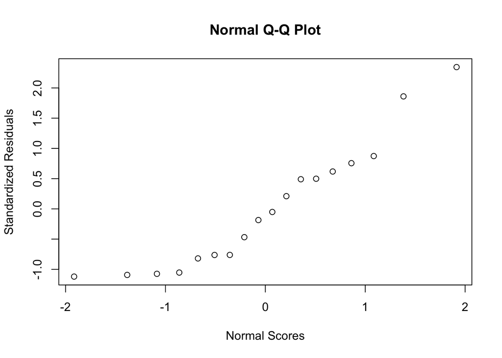

```r
Allison.stdres = rstandard(Allison_lm)

qqnorm(Allison.stdres,
       ylab="Standardized Residuals",
       xlab="Normal Scores")
```

## **Spelling by State**

Now we are looking at the different spellings of Allison’s friend Allan!

## Evidence 4: Q. 1

1. Narrow the A name dataset (downloaded previously) down to only male-assigned babies named “Allan”, “Alan”, or “Allen”. Make a plot comparing the popularity of these names over time.

For this visualization, I was quite mixed about using `position = "dodge"` or `position = "fill"` . I decided I liked the dodge one better for this graph :)

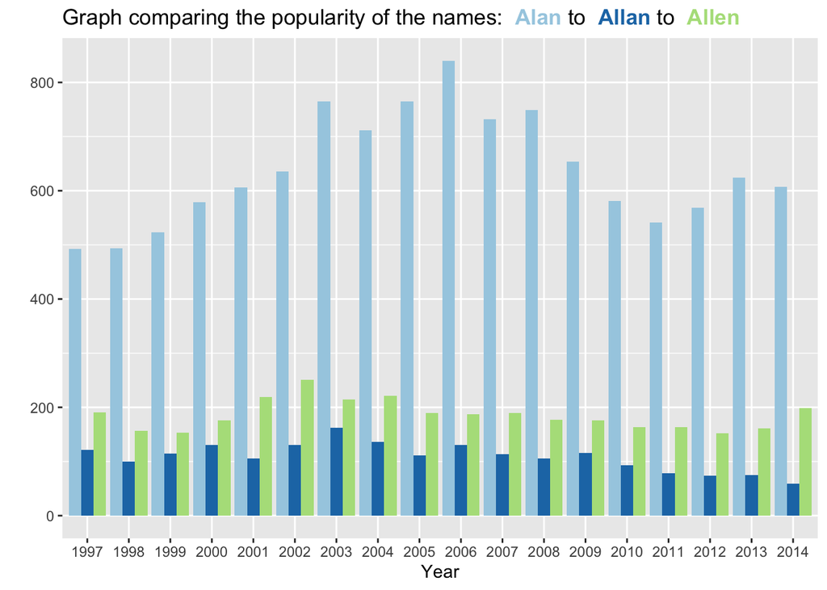

```r
Allans <- StateNames_A |>
  filter(Name %in% c("Allan",
                     "Alan",
                     "Allen")
         ) |>
  mutate(Gender = as.factor(Gender),
         Gender = fct_recode(Gender,
                             Female = "F",
                             Male = "M")
         ) |>
  pivot_wider(names_from = Gender,
              values_from = Count) |>
  select(Name, Year, State, Male)


# Making the Visualizations
ggplot(data = Allans, mapping = aes(x = as.factor(Year), y = Male, fill = Name)
       ) +
  geom_bar(stat="identity", position = "dodge") +
  scale_fill_brewer(palette = "Paired"
                      ) +
  labs(x = "Year",
       y = "",
       fill = "",
       title = str_c("Graph comparing the popularity of the
                     names:",
                     "<span style = 'color:#A6CEE3'>
                     **Alan**</span>",
                     " to<span style = 'color:#1F78B4'>
                     **Allan**</span>",
                     " to<span style = 'color:#B2DF8A'>
                     **Allen**</span>")
      ) +
  theme(plot.title = element_markdown(),
        legend.position = "none")
```

2. In California, Allan’s spelling of his name is the least common of the three
- Creating a table for the three spellings of Allan in 2000 for Pennsylvania and California.

```r
Allans1 <- Allans |>
  pivot_wider(names_from = Name,
              values_from = Male) |>
  filter(State %in% c("CA", "PA"),
         Year == 2000)

# Making the table
knitr::kable(Allans1,
             col.names = gsub(pattern = "[.]",
                              replacement = " ",
                              x = names(Allans1)
                          ),
             align = c("rclll"))
```

| Year | State | Allen | Alan | Allan |
| --- | --- | --- | --- | --- |
| 2000 | CA | 176 | 579 | 131 |
| 2000 | PA | 56 | 51 | 12 |

## Evidence 5: Q. 3

3. Converting the total counts to overall percents.

```r
Allans2 <- Allans |>
  filter(State %in% c("CA", "PA"),
         Year == 2000) |>
  pivot_wider(names_from = State,
              values_from = Male) |>
  mutate(across(CA:PA, ~ . / sum(.) * 100),
         across(CA:PA, ~round(., 1))) |>
  pivot_longer(cols = CA:PA, names_to = "State", values_to = "Percent") |>
  pivot_wider(names_from = Name,
              values_from = Percent)

# Making the Table
knitr::kable(Allans2,
             col.names = c("Year", "State",
                           "% Alan's", "% Allen's",
                           "% Allan's"),
             align = c("rclll")
    )
```

| Year | State | % Alan’s | % Allen’s | % Allan’s |
| --- | --- | --- | --- | --- |
| 2000 | CA | 65.3 | 19.9 | 14.8 |
| 2000 | PA | 42.9 | 47.1 | 10.1 |